# Bulk RNA

Morettini Francesco

2022-02-28

# Introduction

In this Markdown we have an analysis of Bulk RNA-seq data, in particular we have 9 samples coming from 3 different tissues. For each of them three different samples were selected and analysed:

- liver (SRR1324412, SRR1100991, SRR1349479)
- kidney (SRR1486080, SRR1490658, SRR1325483)
- heart (SRR606939, SRR1468613, SRR815184)

The analysis is done using the available packages on Bioconductor and CRAN, in particular with EdgeR. This package implements a range of statistical methodology based on the negative binomial distributions which are used for the computation of differential expression of genes across the samples.

## Libraries

These packagese are needed for different analysis, some of them are useful for the analysis like the mentioned *edgeR*, but also *SummarizedExperiment* and *DESeq2*. Then I have used *tidyverse* which is a collection of packages that include *ggplot2*, *dplyr* and others that are very useful for the manipulation of data. *xlsx* is used for the writing of table in excel format and *biomaRt* is a powerful tool that I have used for retrieving information of any kind on genes and many other things.

```r
library(tidyverse)
library(edgeR)
library(SummarizedExperiment)
library(biomaRt)
library( "DESeq2" )
library(ggplot2)
library("org.Hs.eg.db")
library(kableExtra)
library(recount)
library("xlsx")
`%notin%` <- Negate(`%in%`)
```

## Loading of data

The counts are already normalized and scaled and they should have around 40 millions of reads each. From the table downloaded we have 10 columns which represents 10 different samples, however we only need 3 so I have selected the ones required for the project and saved them in Rdata structure so that they can be loaded already in the right format.

```r
liver <- get(load("rse_gene_liver_9_scaled.Rdata"))
kidney <- get(load("rse_gene_kidney_6_scaled.Rdata"))
heart <- get(load("rse_gene_heart_7_scaled.Rdata"))

liver <- liver[,c(6,7,8)]
kidney <- kidney[,c(9,10,1)]
heart <- heart[,c(1,2,3)]

save(liver, file = "liver.RData")
save(kidney, file = "kidney.RData")
save(heart, file = "heart.RData")

load("liver.RData")
load("kidney.RData")
load("heart.RData")
```

Also some information relative to the data can be retrieved since they are going to be useful for the subsequent analysis. Among those we have the sample Id, the tissue of the sample, the RIN which is the RNA integrity number and the sex.

```r
liver_sex <- c('Male', 'Female', 'Male')
liver_info <- data.frame(liver@colData@rownames, liver@colData@listData[["smtsd"]], liver@colData@listData[["smrin"]],
                    liver_sex)
colnames(liver_info) <- c("Sample", "Tissue", "RIN", "Sex")

kidney_sex <- c('Female', 'Male', 'Male')
kidney_info <- data.frame(kidney@colData@rownames, kidney@colData@listData[["smtsd"]], kidney@colData@listData[["smrin"]],
                         kidney_sex)
colnames(kidney_info) <- c("Sample", "Tissue", "RIN", "Sex")

heart_sex <- c('Female', 'Male', 'Male')
heart_info <- data.frame(heart@colData@rownames, heart@colData@listData[["smtsd"]], heart@colData@listData[["smrin"]],
                         heart_sex)
colnames(heart_info) <- c("Sample", "Tissue", "RIN", "Sex")
sample_info <- rbind(liver_info, kidney_info, heart_info)
```

| Sample | Tissue | RIN | Sex |
| --- | --- | --- | --- |
| SRR1324412 | Liver | 7.9 | Male |
| SRR1100991 | Liver | 7.5 | Female |
| SRR1349479 | Liver | 8.3 | Male |
| SRR1486080 | Kidney - Cortex | 5.9 | Female |
| SRR1490658 | Kidney - Cortex | 6.5 | Male |
| SRR1325483 | Kidney - Cortex | 5.7 | Male |
| SRR606939 | Heart - Left Ventricle | 8.1 | Female |
| SRR1468613 | Heart - Left Ventricle | 8.1 | Male |
| SRR815184 | Heart - Atrial Appendage | 6.8 | Male |

## Stats table

This table will list some of the main statistics of our samples. With the `build_table` function I search for the number of short RNA genes, which are those shorter than 200bp, and the mitochondrial genes which are on the chromosome m (*chrM*). Genes which are both short and mitochondrial are counted as short only as indicated in question 1. Also I compute the percentage of reads that are found on those genes.

```r
build_table <- function(X, tissue){
  tissue <- tissue
  columns <- colnames(X)
  rse <- as.data.frame(X@rowRanges)
  read_counts <- as.data.frame(assay(X))

  total_reads <- colSums(read_counts)

  short_genes <- rse %>% filter(bp_length < 200)
  reads_short_genes <- colSums(read_counts[short_genes$gene_id, ])
  percentage_short_reads <- reads_short_genes/total_reads * 100

  new_rse <- filter(rse, bp_length >= 200)

  MT_genes <- new_rse %>% filter(seqnames == "chrM")
  reads_MT_genes <- colSums(read_counts[MT_genes$gene_id, ])
  percentage_MT_reads <- reads_MT_genes / total_reads * 100

  df <- data.frame(rep(tissue, 3), columns, rep(nrow(short_genes), 3), rep(nrow(MT_genes), 3), total_reads,
                   reads_short_genes, percentage_short_reads, reads_MT_genes, percentage_MT_reads)
  colnames(df) <- c("Tissue", "Sample", "Number of short genes", "Number of MT genes", "Total reads",
                    "Number of reads on short RNAs", "Percentage of reads on short RNAs", "Number of reads on MT genes",
                    "Percentage of reads on MT genes")
  return(df)
}

liver_table <- build_table(liver, "liver")
kidney_table <- build_table(kidney, "kidney")
heart_table <- build_table(heart, "heart")

stats_table <- rbind(liver_table, kidney_table, heart_table)
```

|  | Tissue | Sample | Number of short genes | Number of MT genes | Total reads | Number of reads on short RNAs | Percentage of reads on short RNAs | Number of reads on MT genes | Percentage of reads on MT genes |
| --- | --- | --- | --- | --- | --- | --- | --- | --- | --- |
| SRR1324412 | liver | SRR1324412 | 7341 | 15 | 38357465 | 117082 | 0.3052391 | 6741313 | 17.574970 |
| SRR1100991 | liver | SRR1100991 | 7341 | 15 | 39623912 | 72135 | 0.1820492 | 4903999 | 12.376363 |
| SRR1349479 | liver | SRR1349479 | 7341 | 15 | 40990128 | 57072 | 0.1392335 | 3307191 | 8.068262 |
| SRR1486080 | kidney | SRR1486080 | 7341 | 15 | 37979700 | 119836 | 0.3155265 | 5634358 | 14.835183 |
| SRR1490658 | kidney | SRR1490658 | 7341 | 15 | 39130848 | 152567 | 0.3898893 | 17989699 | 45.973190 |
| SRR1325483 | kidney | SRR1325483 | 7341 | 15 | 36777294 | 77805 | 0.2115572 | 18295922 | 49.747874 |
| SRR606939 | heart | SRR606939 | 7341 | 15 | 38788919 | 105861 | 0.2729156 | 12467758 | 32.142577 |
| SRR1468613 | heart | SRR1468613 | 7341 | 15 | 39229440 | 121991 | 0.3109680 | 14936858 | 38.075634 |
| SRR815184 | heart | SRR815184 | 7341 | 15 | 37043909 | 59684 | 0.1611169 | 6376484 | 17.213313 |

# Preprocessing

## Creation of the count table

For every sample we need to build a count table, from that we will be able to build a DGEList object that will be used for the analysis.

```r
count_table <- function(X){
  rse <- as.data.frame(X@rowRanges)
  read_counts <- as.data.frame(assay(X))
  keep_genes <- rse %>% filter(bp_length >= 200 & seqnames != "chrM")

  counts_keep_genes <- read_counts[keep_genes$gene_id, ]
}

counts_table_liver <- count_table(liver)
counts_table_kidney <- count_table(kidney)
counts_table_heart <- count_table(heart)

counts_table <- cbind(counts_table_liver, counts_table_kidney, counts_table_heart)
```

|  | SRR1324412 | SRR1100991 | SRR1349479 | SRR1486080 | SRR1490658 | SRR1325483 | SRR606939 | SRR1468613 | SRR815184 |
| --- | --- | --- | --- | --- | --- | --- | --- | --- | --- |
| ENSG00000000003.14 | 1915 | 1937 | 2258 | 1095 | 889 | 638 | 182 | 179 | 412 |
| ENSG00000000005.5 | 1 | 0 | 2 | 45 | 8 | 3 | 4 | 5 | 1 |
| ENSG00000000419.12 | 400 | 528 | 974 | 685 | 463 | 527 | 561 | 574 | 534 |
| ENSG00000000457.13 | 591 | 614 | 447 | 723 | 345 | 346 | 293 | 263 | 334 |
| ENSG00000000460.16 | 291 | 419 | 343 | 357 | 111 | 154 | 137 | 124 | 213 |
| ENSG00000000938.12 | 155 | 375 | 1252 | 1368 | 110 | 209 | 127 | 281 | 834 |

## Creation of DGEList object

From the creation of this object we can see many information on our data. For example we can see an header of the count table and also something about the samples like the original library size, after the removal of reads on short genes and mitochondrial genes, the samples name and their tissue, but more importantly the normalization factor that at the moment is still 1 for every of the samples.

```r
edger_table <- DGEList(counts = counts_table)
groups <- as.factor(c(rep("1_Liver", 3), rep("2_Kidney", 3), rep("3_Heart", 3)))
edger_table$samples$group <- groups
edger_table
```

```
## An object of class "DGEList"
## $counts
##                    SRR1324412 SRR1100991 SRR1349479 SRR1486080 SRR1490658
## ENSG00000000003.14       1915       1937       2258       1095        889
## ENSG00000000005.5           1          0          2         45          8
## ENSG00000000419.12        400        528        974        685        463
## ENSG00000000457.13        591        614        447        723        345
## ENSG00000000460.16        291        419        343        357        111
##                    SRR1325483 SRR606939 SRR1468613 SRR815184
## ENSG00000000003.14        638       182        179       412
## ENSG00000000005.5           3         4          5         1
## ENSG00000000419.12        527       561        574       534
## ENSG00000000457.13        346       293        263       334
## ENSG00000000460.16        154       137        124       213
## 50676 more rows ...
##
## $samples
##               group lib.size norm.factors
## SRR1324412  1_Liver 31499070            1
## SRR1100991  1_Liver 34647778            1
## SRR1349479  1_Liver 37625865            1
## SRR1486080 2_Kidney 32225506            1
## SRR1490658 2_Kidney 20988582            1
## SRR1325483 2_Kidney 18403567            1
## SRR606939   3_Heart 26215300            1
## SRR1468613  3_Heart 24170591            1
## SRR815184   3_Heart 30607741            1
```

## Filtering

In this step we want to filter out all the genes with no expression at all or low expression across the 9 samples. This is performed by the `filterByExpr` function which determines the genes with a sufficient number of counts to be retained for a statistical analysis. The computation also depends on the library size.

```r
zero_count <- table(rowSums(edger_table$counts == 0) == 9)
keep_genes <- filterByExpr(edger_table, group = groups)
edger_table <- edger_table[keep_genes, , keep.lib.sizes = FALSE]
```

```r
logcpm <- as.data.frame(cpm(edger_table, log = TRUE))
```

Here we can take a look at the base 2 logarithm of the counts per million, we can see that the median for each boxplot is pretty different, hence we need a normalization. The normalization indeed is our following step and we will use TMM. In different colors we can see the 3 tissues: liver kidney and heart.

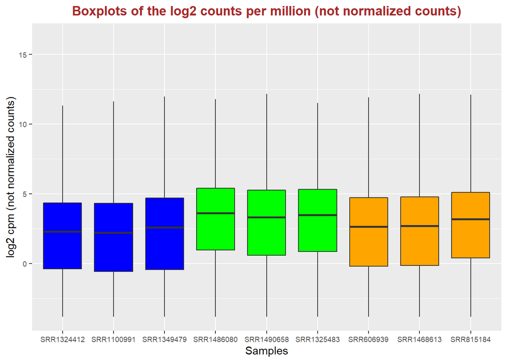

```r
ggplot(stack(logcpm), aes(x = ind, y = values)) + geom_boxplot(outlier.shape = NA,
             fill = rep(c("blue","green","orange"),each=3)) + xlab("Samples") + ylab("log2 cpm (not normalized counts)") +
             ggtitle("Boxplots of the log2 counts per million (not normalized counts)") +
             theme(plot.title = element_text(hjust = 0.5, face = "bold", colour = "brown"),
                   axis.text = element_text(size = 7))
```

## Normalization

Once we have filtered for:

- Short genes
- Mitochondrial genes
- Low or not expressed genes

We can now normalize the counts according to the TMM which is the standard method for `edgeR`. The result of this operation is a change in the normalization factors of our DGEList object. The product of those factors with the original library size give us the effective library size which is the one used in downstream analysis.

```r
edger_table <- calcNormFactors(edger_table, method = "TMM")
edger_table
```

```
## An object of class "DGEList"
## $counts
##                    SRR1324412 SRR1100991 SRR1349479 SRR1486080 SRR1490658
## ENSG00000000003.14       1915       1937       2258       1095        889
## ENSG00000000419.12        400        528        974        685        463
## ENSG00000000457.13        591        614        447        723        345
## ENSG00000000460.16        291        419        343        357        111
## ENSG00000000938.12        155        375       1252       1368        110
##                    SRR1325483 SRR606939 SRR1468613 SRR815184
## ENSG00000000003.14        638       182        179       412
## ENSG00000000419.12        527       561        574       534
## ENSG00000000457.13        346       293        263       334
## ENSG00000000460.16        154       137        124       213
## ENSG00000000938.12        209       127        281       834
## 24125 more rows ...
##
## $samples
##               group lib.size norm.factors
## SRR1324412  1_Liver 31469933    0.6698993
## SRR1100991  1_Liver 34622367    0.6448025
## SRR1349479  1_Liver 37600531    0.7748356
## SRR1486080 2_Kidney 32163050    1.5616042
## SRR1490658 2_Kidney 20965476    1.2742129
## SRR1325483 2_Kidney 18367437    1.4158253
## SRR606939   3_Heart 26182539    0.9385288
## SRR1468613  3_Heart 24147620    0.9597117
## SRR815184   3_Heart 30549176    1.1774518
```

### Genes left after the filtering

Here I report a table which summarize all the filtering steps. In the end we still have **24130** for the analysis. This table is build considering the liver samples, however the results are the same also for kidney and heart.

```r
total_genes <- nrow(assay(liver))
short_genes <- stats_table$`Number of short genes`[1]
mt_genes <- stats_table$`Number of MT genes`[1]
after_short_genes <- total_genes - stats_table$`Number of short genes`[1]
after_MT_genes <- after_short_genes - stats_table$`Number of MT genes`[1]
after_low_exp <- nrow(edger_table$counts)
low_expr <- after_MT_genes - after_low_exp
number_genes <- data.frame(total_genes, short_genes, after_short_genes, mt_genes, after_MT_genes, low_expr, after_low_exp)
colnames(number_genes) <- c("Total number of genes", "Short genes" ,"After filter for short genes",
                            "Mitochondiral genes", "After filter for MT genes", "Low expression",
                            "After filter for low expression")
```

| Total number of genes | Short genes | After filter for short genes | Mitochondiral genes | After filter for MT genes | Low expression | After filter for low expression |
| --- | --- | --- | --- | --- | --- | --- |
| 58037 | 7341 | 50696 | 15 | 50681 | 26551 | 24130 |

## Plots

Here we can see the boxplots for each of the 9 samples where we represent the base 2 logarithm of the normalized counts, expressed in counts per million. It is easy to see that after the normalization the mean value for each sample is pretty much the same.

```r
logcpm <- as.data.frame(cpm(edger_table, log = TRUE))
```

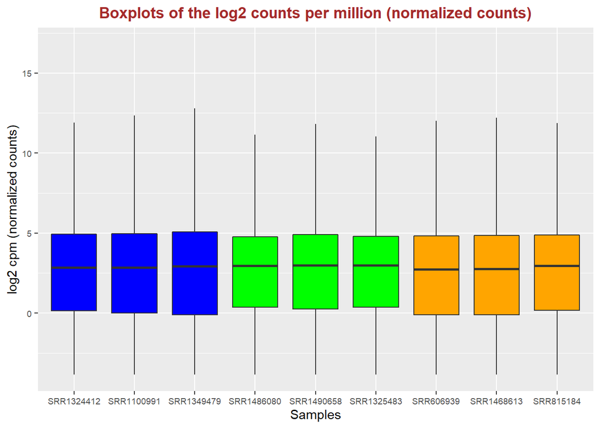

```r
ggplot(stack(logcpm), aes(x = ind, y = values)) + geom_boxplot(outlier.shape = NA,
             fill = rep(c("blue","green","orange"),each=3)) + xlab("Samples") + ylab("log2 cpm (normalized counts)") +
             ggtitle("Boxplots of the log2 counts per million (normalized counts)") +
             theme(plot.title = element_text(hjust = 0.5, face = "bold", colour = "brown"),
                   axis.text = element_text(size = 7))
```

## RNA integrity number (RIN)

RNA integrity number is a score associated to each RNA sample. In particular is a 2D plot which is used to measure RNA integrity. The plot give us the distribution of the size of RNAs, and we want them to be still integer, so a good result would be to have 2 (3 if we consider 5s) clear peaks representing the rRNA subunits (18s, 28s). All other RNAs length should be random and for this reason we should not see any other peak. If other peaks appeared it means that our RNA is degraded and we are left with small pieces of RNA. The score, that goes from 1 (very bad) to 10 (very good), measure the goodness of the plot. This is not manually computed, but the number is the result of a machine learning algorithm trained with plots annotated by experts. We consider as a threshold for reliable results a RIN of 7. We can see in the plot that overall liver and heart scores are pretty good whereas the RIN value for the kidney samples is low.

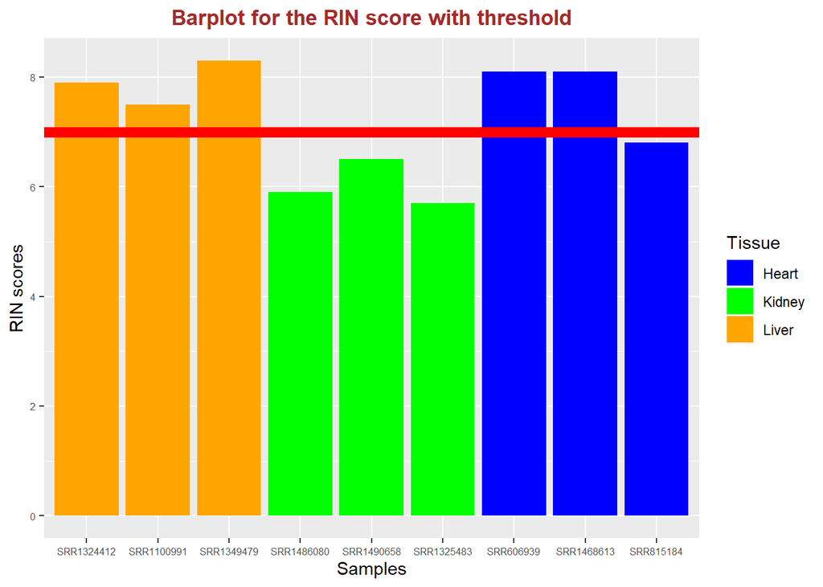

```r
RIN <- dplyr::select(sample_info, Sample, RIN)
RIN$Tissue <- c(rep("Liver", 3), rep("Kidney", 3), rep("Heart", 3))

ggplot(RIN, aes(x = Sample, y = RIN, fill = Tissue)) + geom_col() +
  xlab("Samples") + ylab("RIN scores") + ggtitle("Barplot for the RIN score with threshold") +
  theme(plot.title = element_text(hjust = 0.5, face = "bold", colour = "brown"), axis.text = element_text(size = 6)) +
  geom_hline(yintercept = 7, color = "red", size = 3) +
  scale_x_discrete(limits = RIN$Sample) + scale_fill_manual(values=c("blue", "green", "orange"))
```

## Linear model

Now we have to build the model for our experiment. It is a linear model in which we don’t have a reference condition because we are not in a disease-control setting and also our 3 tissue are not related. So it makes sense to build a model without an intercept.

```r
design_matrix <- model.matrix(~0 + group, data = edger_table$samples)
colnames(design_matrix) <- levels(edger_table$samples$group)
design_matrix
```

```
##            1_Liver 2_Kidney 3_Heart
## SRR1324412       1        0       0
## SRR1100991       1        0       0
## SRR1349479       1        0       0
## SRR1486080       0        1       0
## SRR1490658       0        1       0
## SRR1325483       0        1       0
## SRR606939        0        0       1
## SRR1468613       0        0       1
## SRR815184        0        0       1
## attr(,"assign")
## [1] 1 1 1
## attr(,"contrasts")
## attr(,"contrasts")$group
## [1] "contr.treatment"
```

```r
tissue <- c(rep("Liver", 3), rep("Kidney", 3), rep("Heart", 3))
samples <- stats_table$Sample
```

### Dimensionality reduction

Now that we have the normalized expression of genes in our samples we can plot them to see if samples of the same tissue are similar and if samples of different tissues are well separated. So ideally, since we have 3 tissues we expect to see our 9 samples divided in 3 well separated clusters. However, we have more than 20000 genes so to plot all of them we would need more than 20000 dimensions which obviously we can’t visualize. To solve this problem we use dimensionality reduction techniques, in our specific case we have two options which are multi-dimensional scaling (MDS) and principal component analysis (PCA). With both of them we can project our data in a 2 dimensional space where the 2 axis are computed such that we preserve as much as possible the variance of our data; preserving the variance of the data means preserve the information that they have. MDS instead of expression use the fold ratio values among the three samples to compute the principal components. In the following plots we can see both MDS and PCA, the first plot use as labels the samples while the second one the tissues. On the axis we can see the percentage of variance, with respect to the old space, that the new components are able to explain.

It is easy to see that the tissues cluster very well, in fact we have high intra-cluster similarity and low inter-cluster similarity.

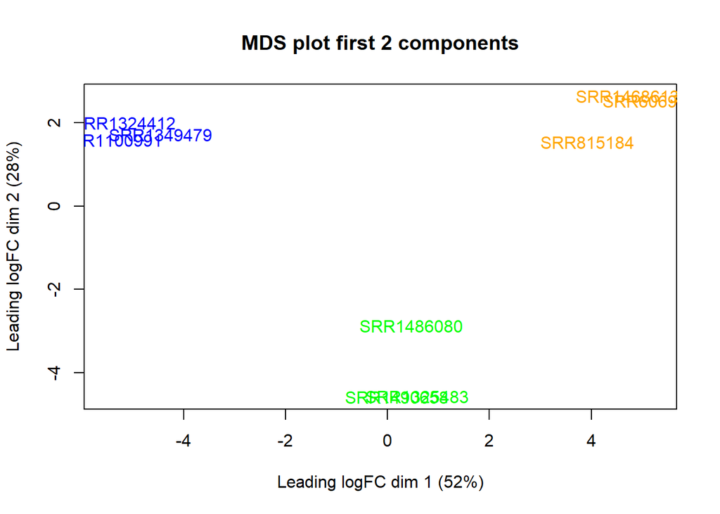

```r
plotMDS(logcpm, labels = samples, col = rep(c("blue", "green", "orange"), each = 3), main = "MDS plot first 2 components")
```

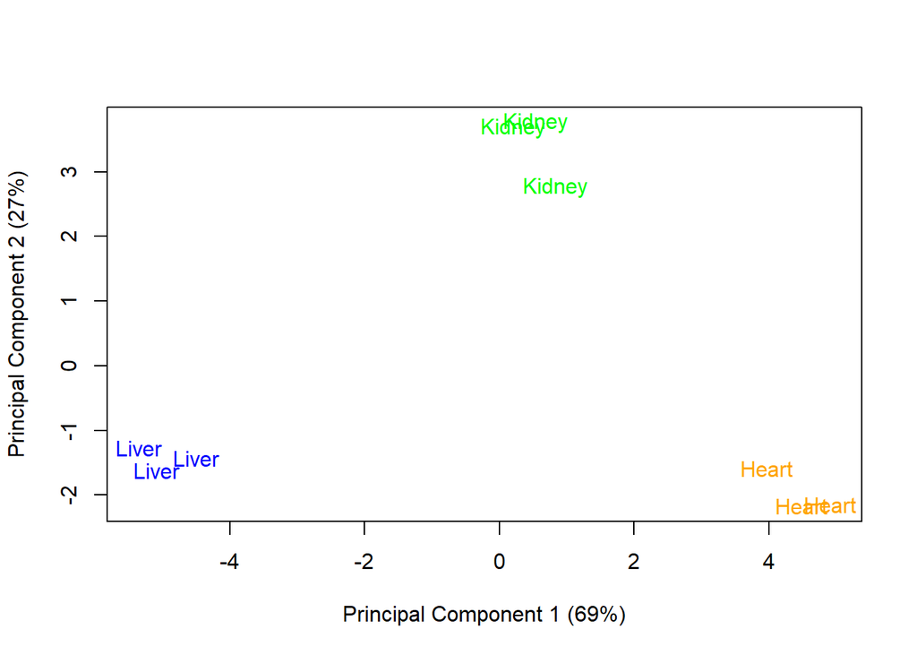

```r
plotMDS(logcpm, labels = tissue, gene.selection = "common", col = rep(c("blue", "green", "orange"), each = 3, main = "PCA first 2 components"))
```

Just for curiosity we can try to plot the same thing however not using the 2 principal components, we can see that we are still able to identify clusters using the first and the third principal component, but if we use for example the third and the fourth than we are not able anymore to distinguish between the tissues. This is due to the fact that those components are associated with no or little information as we can see from the percentage of variability explained.

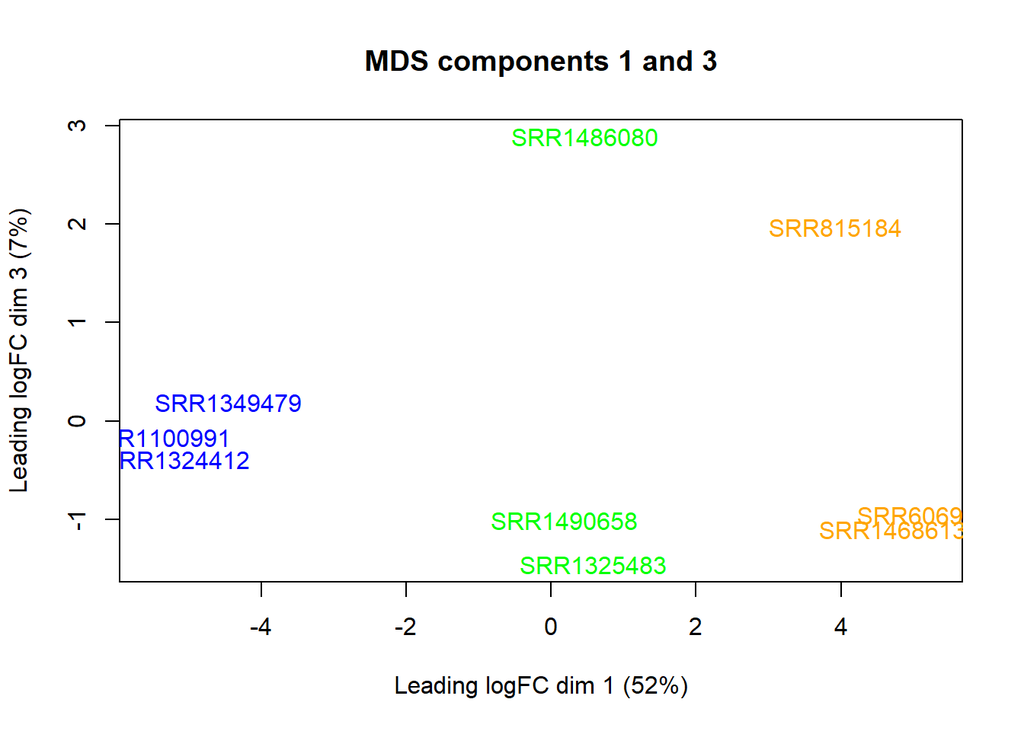

```r
plotMDS(logcpm, labels = samples, col = rep(c("blue", "green", "orange"), each = 3), dim.plot = c(1,3), main = "MDS components 1 and 3")
```

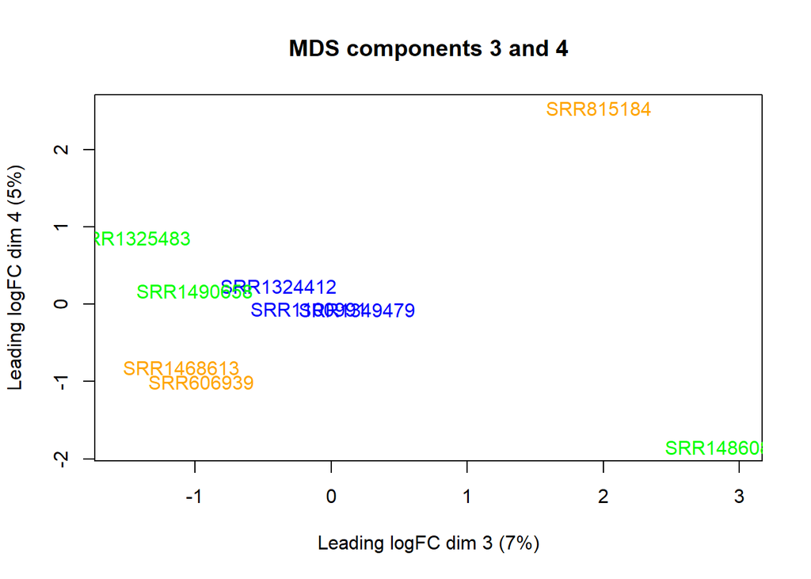

```r
plotMDS(logcpm, labels = samples, col = rep(c("blue", "green", "orange"), each = 3), dim.plot = c(3,4), main = "MDS components 3 and 4")
```

### Additional factors

| Sample | RIN | Sex |
| --- | --- | --- |
| SRR1324412 | 7.9 | Male |
| SRR1100991 | 7.5 | Female |
| SRR1349479 | 8.3 | Male |
| SRR1486080 | 5.9 | Female |
| SRR1490658 | 6.5 | Male |
| SRR1325483 | 5.7 | Male |
| SRR606939 | 8.1 | Female |
| SRR1468613 | 8.1 | Male |
| SRR815184 | 6.8 | Male |

Then we can plot the results as before

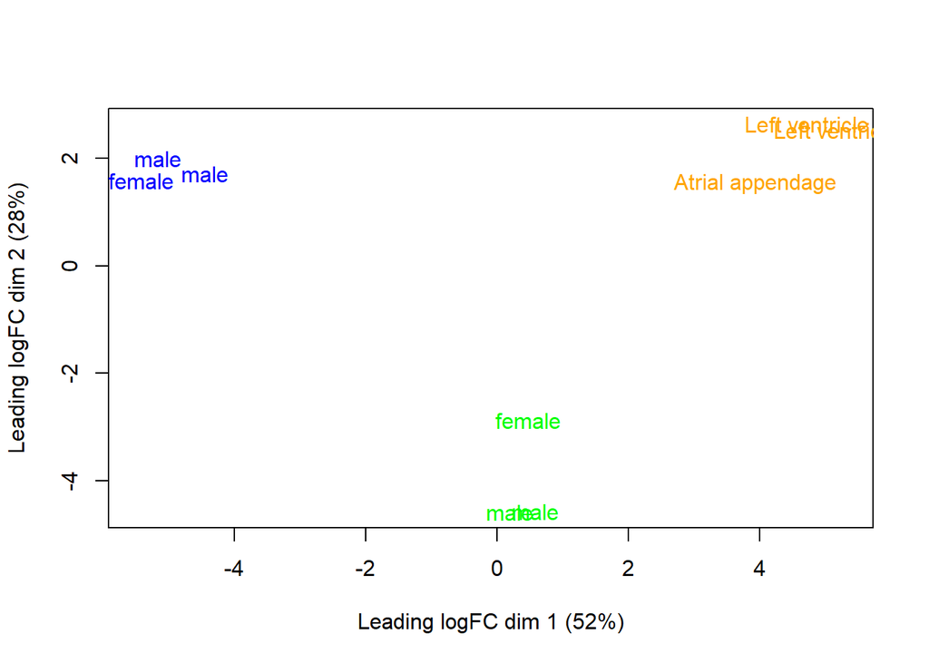

```r
factors <- c("male", "female", "male", "female", "male", "male", rep("Left ventricle", 2), "Atrial appendage")
plotMDS(logcpm, labels = factors, col = rep(c("blue","green","orange"),each = 3, main = "MDS components 1 and 2 with specific factors"))
```

## Dispersion estimation

Here we can compute the variability which is present in my samples. To do that we follow the guidelines of edgeR and we use the negative binomial distribution. With this kind of distribution in fact we can take into account the variability both at biological and technical level. We can represent the results using the BCV plot in which we have the genewise biological coefficient of variation (BCV) against gene abundance (in log2 counts per million).

```r
edger_table <- estimateDisp(edger_table, design_matrix)
edger_table
```

```
## An object of class "DGEList"
## $counts
##                    SRR1324412 SRR1100991 SRR1349479 SRR1486080 SRR1490658
## ENSG00000000003.14       1915       1937       2258       1095        889
## ENSG00000000419.12        400        528        974        685        463
## ENSG00000000457.13        591        614        447        723        345
## ENSG00000000460.16        291        419        343        357        111
## ENSG00000000938.12        155        375       1252       1368        110
##                    SRR1325483 SRR606939 SRR1468613 SRR815184
## ENSG00000000003.14        638       182        179       412
## ENSG00000000419.12        527       561        574       534
## ENSG00000000457.13        346       293        263       334
## ENSG00000000460.16        154       137        124       213
## ENSG00000000938.12        209       127        281       834
## 24125 more rows ...
##
## $samples
##               group lib.size norm.factors
## SRR1324412  1_Liver 31469933    0.6698993
## SRR1100991  1_Liver 34622367    0.6448025
## SRR1349479  1_Liver 37600531    0.7748356
## SRR1486080 2_Kidney 32163050    1.5616042
## SRR1490658 2_Kidney 20965476    1.2742129
## SRR1325483 2_Kidney 18367437    1.4158253
## SRR606939   3_Heart 26182539    0.9385288
## SRR1468613  3_Heart 24147620    0.9597117
## SRR815184   3_Heart 30549176    1.1774518
##
## $design
##            1_Liver 2_Kidney 3_Heart
## SRR1324412       1        0       0
## SRR1100991       1        0       0
## SRR1349479       1        0       0
## SRR1486080       0        1       0
## SRR1490658       0        1       0
## SRR1325483       0        1       0
## SRR606939        0        0       1
## SRR1468613       0        0       1
## SRR815184        0        0       1
## attr(,"assign")
```

[output cut: 17 more lines]

```
## $AveLogCPM
## [1] 5.329266 4.402435 4.006190 3.132869 4.036877
## 24125 more elements ...
##
## $trend.method
## [1] "locfit"
##
## $prior.df
## [1] 3.280255
##
## $prior.n
## [1] 0.5467092
##
## $span
## [1] 0.2841403
```

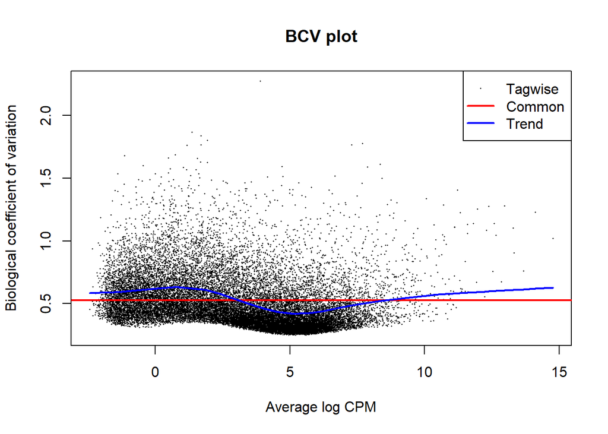

```r
plotBCV(edger_table, main = "BCV plot")
```

## Model fitting

Now we want to find which are the genes differentially expressed in our tissues. To do that we need to build a model which is a generalized linear model. The reason for which we are building this kind of model is that since we previously considered the Negative Binomial distribution we can’t build a simple linear model because this is based on the assumption that data are normally distributed. Also we have the advantage that we can compare more than 2 conditions at the same time. So we build the model with the data that we have treated until now.

```r
model_glm <- glmQLFit(edger_table, design_matrix)
```

Once we have build the model we can use it to test whether genes are differentially expressed between two samples. We will start by doing three different comparisons:

- Liver vs Kidney
- Liver vs Heart
- Kidney vs Heart

To do those comparison we have to explicit the two tissues we are considering and for which one we are going to compute the up-regulated and down-regulated genes. Also, since we are considering more than 20000 genes in our analysis we will have to consider multiple test correction. We have many different options when it comes to this, some are more stringent than others, for example Bonferroni is the more stringent one, where all the p-values are corrected in the same way. This type of correction decrease the number of false positives, which is certainly good, however it increases a lot the number of false negatives; increasing too much the number of false negatives may not be what we want because we may loose many information. Also this type of correction is based on the assumption that tests are not correlated, however this is not the case. For those reasons Bonferroni is not used anymore. Other correction which are progressively less stringent are Bonferroni-Holm, Westfall and Young based on permutations and finally Benjamini Hochberg or false discovery rate (FDR) which is the one that we are going to use. As a threshold for considering a gene differentially expressed we will consider both the adjusted p-value, which should be lower than a certain threshold (usually 0.05 but 0.01 may work better) and also the log2fold change, for which the absolute value should be usually greater than 1. It will be smaller than -1 for down-regulated genes and greater than 1 for up-regulated.

We start by applying our model to the different couple of tissues and computing the adjusted p-values.

```r
Liver_vs_Kidney <- glmQLFTest(model_glm, contrast = c(1,-1,0))
Liver_vs_Heart <- glmQLFTest(model_glm, contrast = c(1,0,-1))
Kidney_vs_Heart <- glmQLFTest(model_glm, contrast = c(0,1,-1))

FDR_Liver_vs_Kidney <- p.adjust(Liver_vs_Kidney$table$PValue, method = "BH")
FDR_Liver_vs_Heart <- p.adjust(Liver_vs_Heart$table$PValue, method = "BH")
FDR_Kidney_vs_Heart <- p.adjust(Kidney_vs_Heart$table$PValue, method = "BH")
```

Now we have to decide which thresholds to use in order to obtain meaningful results. In a first moment I have tried to use the canonical values: a level of significance of $\alpha = 0.05$ for the adjusted p-values and an absolute value of 1 for the log2FC.

**Liver vs Kidney:**

```r
summary(decideTests(Liver_vs_Kidney, lfc = 1))
```

```
##        1*1_Liver -1*2_Kidney
## Down                    2404
## NotSig                 19954
## Up                      1772
```

**Liver vs Heart:**

```r
summary(decideTests(Liver_vs_Heart, lfc = 1))
```

```
##        1*1_Liver -1*3_Heart
## Down                   3530
## NotSig                17305
## Up                     3295
```

**Kidney vs Heart:**

```r
summary(decideTests(Kidney_vs_Heart, lfc = 1))
```

```
##        1*2_Kidney -1*3_Heart
## Down                    1596
## NotSig                 20440
## Up                      2094
```

Already here we can see that using those thresholds we obtain many differentially expressed genes. In general we would like to have around a thousands of DE genes, although there is not a precise rule. Continuing the pipeline with those parameters result in a poor functional enrichment analysis so I have decided to lower the thresholds using a more stringent value of $\alpha = 0.01$ mantaining the same value for the log2FC.

**Liver vs Kidney:**

```r
summary(decideTests(Liver_vs_Kidney, lfc = 1, p.value = 0.01))
```

```
##        1*1_Liver -1*2_Kidney
## Down                     985
## NotSig                 22379
## Up                       766
```

**Liver vs Heart:**

```r
summary(decideTests(Liver_vs_Heart, lfc = 1, p.value = 0.01))
```

```
##        1*1_Liver -1*3_Heart
## Down                   1820
## NotSig                20426
## Up                     1884
```

**Kidney vs Heart:**

```r
summary(decideTests(Kidney_vs_Heart, lfc = 1, p.value = 0.01))
```

```
##        1*2_Kidney -1*3_Heart
## Down                     644
## NotSig                 22558
## Up                       928
```

Once we have computed the number of differentially expressed genes we can also find the using the function `topTags`. In this way we can obtain a dataframe in which we have all the DE genes with the associated adjusted p-value and the log2FC. Given the log2FC we can also say if they are up or down regulated. So we create three dataframes, one for each of the comparisons that we have done.

```r
tags_LK <- topTags(Liver_vs_Kidney, n = 5000, adjust.method = "BH", sort.by = "PValue", p.value = 0.01)$table
tags_LH <- topTags(Liver_vs_Heart, n = 5000, adjust.method = "BH", sort.by = "PValue", p.value = 0.01)$table
tags_KH <- topTags(Kidney_vs_Heart, n = 5000, adjust.method = "BH", sort.by = "PValue", p.value = 0.01)$table
tags_LK$DE <- ifelse(tags_LK$logFC > 1, "Up", "Down")
tags_LH$DE <- ifelse(tags_LH$logFC > 1, "Up", "Down")
tags_KH$DE <- ifelse(tags_KH$logFC > 1, "Up", "Down")
```

We can visualize the header of one or them.

|  | logFC | logCPM | F | PValue | FDR | DE |
| --- | --- | --- | --- | --- | --- | --- |
| ENSG00000125551.18 | 7.188016 | 5.943816 | 371.8825 | 0 | 8.04e-05 | Up |
| ENSG00000136574.17 | 8.966787 | 5.885492 | 360.2041 | 0 | 8.04e-05 | Up |
| ENSG00000080618.13 | 14.652650 | 8.131462 | 332.6829 | 0 | 8.04e-05 | Up |
| ENSG00000235910.1 | 12.311016 | 8.529987 | 331.0825 | 0 | 8.04e-05 | Up |
| ENSG00000144852.16 | 9.014746 | 5.361092 | 319.1581 | 0 | 8.04e-05 | Up |
| ENSG00000253215.1 | 13.222388 | 7.047408 | 306.9865 | 0 | 8.04e-05 | Up |

Now that we have these dataframes we compute all the genes that are up or down regulated in one tissue with respect to another for all the possible combinations of the 3 tissues. In the end we will have 6 list of genes which are up-regulated and 6 down-regulated, one for each comparison:

- Liver vs Kidney
- Kidney vs Liver
- Liver vs Heart
- Heart vs Liver
- Kidney vs Heart
- Heart vs Kidney

```r
up_LK <- tags_LK %>% dplyr::select(-6) %>% filter(logFC > 1)
down_LK <- tags_LK %>% dplyr::select(-6) %>% filter(logFC < -1)
up_KL <- down_LK
down_KL <- up_LK

up_LH <- tags_LH %>% dplyr::select(-6) %>% filter(logFC > 1)
down_LH <- tags_LH %>% dplyr::select(-6) %>% filter(logFC < -1)
up_HL <- down_LH
down_HL <- up_LH

up_KH <- tags_KH %>% dplyr::select(-6) %>% filter(logFC > 1)
down_KH <- tags_KH %>% dplyr::select(-6) %>% filter(logFC < -1)
up_HK <- down_KH
down_HK <- up_KH
```

As final step of this analysis we want to find the genes that are up-regulated or down-regulated in both the comparison with respect to the other 2 tissues. To do that we look for the genes that are found in both the previous dataframes for a certain tissue.

```r
up_Liver <- merge(up_LK, up_LH, by = 0, all = FALSE)
down_Liver <- merge(down_LK, down_LH, by = 0, all = FALSE)

up_Kidney <- merge(up_KH, up_KL, by = 0, all = FALSE)
down_Kidney <- merge(down_KH, down_KL, by = 0, all = FALSE)

up_Heart <- merge(up_HK, up_HL, by = 0, all = FALSE)
down_Heart <- merge(down_HK, down_HL, by = 0, all = FALSE)
```

To make the results of the analysis more clear they are written in excel file present in the supplementary material.

```r
write.xlsx(tags_LK, file = "Supplementary.xlsx",
           sheetName = "Liver vs Kidney", append = FALSE)

write.xlsx(tags_LH, file = "Supplementary.xlsx",
           sheetName = "Liver vs Heart", append=TRUE)

write.xlsx(tags_KH, file = "Supplementary.xlsx",
           sheetName = "Kidney vs Heart", append=TRUE)

write.xlsx(up_Heart, file = "Supplementary.xlsx",
           sheetName = "Up Heart", append = TRUE)

write.xlsx(down_Heart, file = "Supplementary.xlsx",
           sheetName = "Down Heart", append = TRUE)

write.xlsx(up_Kidney, file = "Supplementary.xlsx",
           sheetName = "Up Kidney", append = TRUE)

write.xlsx(down_Kidney, file = "Supplementary.xlsx",
           sheetName = "Down Kidney", append = TRUE)

write.xlsx(up_Liver, file = "Supplementary.xlsx",
           sheetName = "Up Liver", append = TRUE)

write.xlsx(down_Liver, file = "Supplementary.xlsx",
           sheetName = "Down Liver", append = TRUE)
```

## Functional enrichment analysis

After having discovered the genes that are differentially expressed we want to perform a functional enrichment analysis on them. Basically we want to see if they are enriched for certain pathways. To do that we can use different software such as DAVID Enrichr and GSEA. To use them we have to provide those with a gene set, however, not all of them accept the ensembl gene ID but they should be provided with the gene symbols. In order to do that we can use biomart which is a project that provides access to many distributed research data. We can query biomart with our set of genes and it will return all the information that we want included the gene symbol. With this tool we can retrieve the majority of gene symbols, however not all of them since there is some disparity between the notations. In fact working with these lists of genes is easy to find duplicated ensembl gene id, or ensembl gene id that corresponds to multiple gene symbols or sometimes the gene id may be associated with an alias of the gene symbol. The query is done on homo sapiens gene ensembl dataset. Fianlly before querying our list of genes we have to remove the version from the gene ID which are the numbers after the dot. The function also produce a .txt file that can be used for the functional annotation analysis.

```r
ensembl <- useEnsembl(biomart = "genes", dataset = "hsapiens_gene_ensembl")

retrieve_names <- function(genes, tissue){
  ensembl_ID <- genes$Row.names
  ensembl_ID <- gsub("\\..*", "", ensembl_ID)
  all_genes_ensg <- getBM(mart = ensembl,
                          attributes = c('hgnc_symbol', 'ensembl_gene_id', 'chromosome_name'),
                          filters = "ensembl_gene_id",
                          values = ensembl_ID)
  all_genes_ensg <- all_genes_ensg[complete.cases(all_genes_ensg), ]
  all_genes_ensg <- all_genes_ensg[!(is.na(all_genes_ensg$hgnc_symbol) | all_genes_ensg$hgnc_symbol == ""), ]
  write.table(all_genes_ensg$hgnc_symbol, file = paste0("HGNC_symbol_for_DE_genes_", tissue, ".txt"), quote = FALSE,
              col.names = FALSE, row.names = FALSE)
  return(all_genes_ensg)
}


gene_names_up_liver <- retrieve_names(up_Liver, "Liver")
gene_names_up_kidney <- retrieve_names(up_Kidney, "Kidney")
gene_names_up_heart <- retrieve_names(up_Heart, "Heart")
```

| hgnc_symbol | ensembl_gene_id | chromosome_name |
| --- | --- | --- |
| TSPAN6 | ENSG00000000003 | X |
| GCLC | ENSG00000001084 | 6 |
| CYP51A1 | ENSG00000001630 | 7 |
| SLC25A13 | ENSG00000004864 | 7 |
| MPO | ENSG00000005381 | 17 |
| PON1 | ENSG00000005421 | 7 |
| ABCB4 | ENSG00000005471 | 7 |
| BAIAP2L1 | ENSG00000006453 | 7 |
| ADIPOR2 | ENSG00000006831 | 12 |
| FMO3 | ENSG00000007933 | 1 |

## Up regulated gene

We now have to find the gene which is up regulated in the comparison between Liver and Kidney with the lower FDR. Then we want it to be found also in the comparison between Liver and Heart. To do that we use a while a loop that search our gene. Once we have find it we have to check if it has two alternative transcripts on the GENCODE v25 track of the Genome Browser.

```r
cond = TRUE
while (cond){
  #Select the best gene
  best_gene <- rownames(tags_LK[which.min(tags_LK[tags_LH$logFC < -1,]$FDR),])
  #If it is present also in tags_LH will return TRUE and stop the loop
  cond <- best_gene %notin% rownames(tags_LH)
  #However if it is present but the logFC is smaller than -1 it means is downregulated so we don't want him
  if (tags_LH[best_gene, ]$logFC <= -1){
    cond == TRUE
  }
  #If the gene is not present in tags_LH remove it from tags_LK so to select the next one
  tags_LK <- tags_LK %>% filter(row.names(tags_LK) %notin% best_gene)
}
```

Before looking on the genome browser we can also search on biomart how many transcripts are found and which is its position on the genome. As before we have to remove the part that comes after the dot in the ensembl gene id.

```r
best_gene_ens_id <- gsub("\\..*", "", best_gene)
best_gene_table <- getBM(mart = ensembl,
                        attributes = c('ensembl_gene_id', 'ensembl_transcript_id', 'start_position', 'chromosome_name'),
                        filters = "ensembl_gene_id",
                        values = best_gene_ens_id)
```

| ensembl_gene_id | ensembl_transcript_id | start_position | chromosome_name |
| --- | --- | --- | --- |
| ENSG00000125551 | ENST00000359481 | 87748087 | 2 |
| ENSG00000125551 | ENST00000410086 | 87748087 | 2 |
| ENSG00000125551 | ENST00000465361 | 87748087 | 2 |

## RPKM

Finally we compute the RPKM for the previous gene. To do that we need to retrieve all the information which are necessary. Those are the gene length, which is the sum of bp that are constituting an exon, this will be retrieved again with biomart. Than we need the read count associated with the gene and the overall number of reads used for quantification.

```r
best_gene_data <- getBM(mart = ensembl,
                         attributes = c('ensembl_gene_id', 'exon_chrom_start', 'exon_chrom_end', 'ensembl_transcript_id'),
                         filters = "ensembl_gene_id",
                         values = best_gene_ens_id)

best_gene_table <- filter(best_gene_data, ensembl_transcript_id == "ENST00000359481")
best_gene_table$exon_lenght <- best_gene_table$exon_chrom_end - best_gene_table$exon_chrom_start
gene_length <- sum(best_gene_table$exon_lenght)
reads <- as.data.frame(edger_table$samples)$lib.size
counts <- as.data.frame(edger_table$counts)
counts_best_gene <- counts %>% filter(row.names(counts) %in% best_gene)

RPKM <- counts_best_gene * 1000 * 1000000/(reads * gene_length)
```

|  | SRR1324412 | SRR1100991 | SRR1349479 | SRR1486080 | SRR1490658 | SRR1325483 | SRR606939 | SRR1468613 | SRR815184 |
| --- | --- | --- | --- | --- | --- | --- | --- | --- | --- |
| ENSG00000125551.18 | 52.90785 | 37.53264 | 34.00357 | 0.6503219 | 0.4117311 | 0.7049545 | 0.4438143 | 0.4537166 | 0.6303381 |